# HW5 CODE

## PROBLEM 1.

```python
import pandas as pd
import os
import numpy as np

import PIL
from PIL import Image

import matplotlib
from matplotlib import image
from matplotlib import pyplot

base_path = os.getcwd()
```

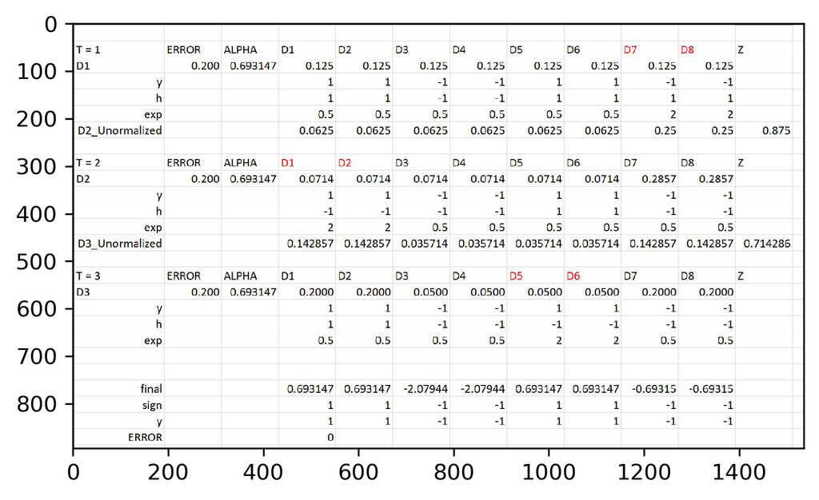

```python
q3_cal = image.imread('q3 excel.JPG')
#pyplot.figure(figsize=(16,8))
matplotlib.rcParams['figure.dpi'] = 300
pyplot.imshow(q3_cal)
pyplot.show()
```

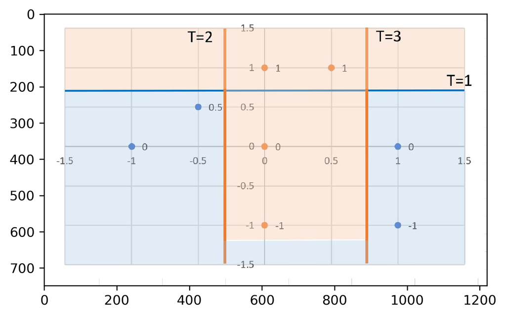

```python
q3_cal = image.imread('boost graph.JPG')
#pyplot.figure(figsize=(8,8))
#matplotlib.rcParams['figure.dpi'] = 200
pyplot.imshow(q3_cal)
pyplot.show()
```

> The accuracy is 100%. Adaboost adjust the weights of incorrectly classified points at each steps, so that they will weigh more at the next step, as well as in the final classifier. Therefore, will be more likely to be correctly classified.

## PROBLEM 2.

### QUESTION 1.

```python
spam = pd.read_table(os.path.join(base_path, "", "spambase.data"),sep = ',')
spam = spam.fillna(0)
```

```python
spam
```

|  | 0 | 0.64 | 0.64.1 | 0.1 | 0.32 | 0.2 | 0.3 | 0.4 | 0.5 | 0.6 | ... | 0.40 | 0.41 | 0.42 | 0.778 | 0.43 | 0.44 | 3.756 | 61 | 278 | 1 |
| --- | --- | --- | --- | --- | --- | --- | --- | --- | --- | --- | --- | --- | --- | --- | --- | --- | --- | --- | --- | --- | --- |
| 0 | 0.21 | 0.28 | 0.50 | 0.0 | 0.14 | 0.28 | 0.21 | 0.07 | 0.00 | 0.94 | ... | 0.000 | 0.132 | 0.0 | 0.372 | 0.180 | 0.048 | 5.114 | 101 | 1028 | 1 |
| 1 | 0.06 | 0.00 | 0.71 | 0.0 | 1.23 | 0.19 | 0.19 | 0.12 | 0.64 | 0.25 | ... | 0.010 | 0.143 | 0.0 | 0.276 | 0.184 | 0.010 | 9.821 | 485 | 2259 | 1 |
| 2 | 0.00 | 0.00 | 0.00 | 0.0 | 0.63 | 0.00 | 0.31 | 0.63 | 0.31 | 0.63 | ... | 0.000 | 0.137 | 0.0 | 0.137 | 0.000 | 0.000 | 3.537 | 40 | 191 | 1 |
| 3 | 0.00 | 0.00 | 0.00 | 0.0 | 0.63 | 0.00 | 0.31 | 0.63 | 0.31 | 0.63 | ... | 0.000 | 0.135 | 0.0 | 0.135 | 0.000 | 0.000 | 3.537 | 40 | 191 | 1 |
| 4 | 0.00 | 0.00 | 0.00 | 0.0 | 1.85 | 0.00 | 0.00 | 1.85 | 0.00 | 0.00 | ... | 0.000 | 0.223 | 0.0 | 0.000 | 0.000 | 0.000 | 3.000 | 15 | 54 | 1 |
| ... | ... | ... | ... | ... | ... | ... | ... | ... | ... | ... | ... | ... | ... | ... | ... | ... | ... | ... | ... | ... | ... |
| 4595 | 0.31 | 0.00 | 0.62 | 0.0 | 0.00 | 0.31 | 0.00 | 0.00 | 0.00 | 0.00 | ... | 0.000 | 0.232 | 0.0 | 0.000 | 0.000 | 0.000 | 1.142 | 3 | 88 | 0 |
| 4596 | 0.00 | 0.00 | 0.00 | 0.0 | 0.00 | 0.00 | 0.00 | 0.00 | 0.00 | 0.00 | ... | 0.000 | 0.000 | 0.0 | 0.353 | 0.000 | 0.000 | 1.555 | 4 | 14 | 0 |
| 4597 | 0.30 | 0.00 | 0.30 | 0.0 | 0.00 | 0.00 | 0.00 | 0.00 | 0.00 | 0.00 | ... | 0.102 | 0.718 | 0.0 | 0.000 | 0.000 | 0.000 | 1.404 | 6 | 118 | 0 |
| 4598 | 0.96 | 0.00 | 0.00 | 0.0 | 0.32 | 0.00 | 0.00 | 0.00 | 0.00 | 0.00 | ... | 0.000 | 0.057 | 0.0 | 0.000 | 0.000 | 0.000 | 1.147 | 5 | 78 | 0 |
| 4599 | 0.00 | 0.00 | 0.65 | 0.0 | 0.00 | 0.00 | 0.00 | 0.00 | 0.00 | 0.00 | ... | 0.000 | 0.000 | 0.0 | 0.125 | 0.000 | 0.000 | 1.250 | 5 | 40 | 0 |

4600 rows × 58 columns

```python
spam.groupby('1').count()['0']
```

```
1
0    2788
1    1812
Name: 0, dtype: int64
```

### ANSWER

> There are 1812 spam emails and 2788 regular emails. There are 4600 data points, and 57 features.

### QUESTION 2.

```python
import numpy as np

from sklearn.tree import DecisionTreeClassifier as DTC
from sklearn.tree import plot_tree
from sklearn.model_selection import train_test_split
from sklearn.model_selection import cross_val_score

X = spam.iloc[:,:-1]
y = spam.iloc[:,-1]

X_train, X_test, y_train, y_test = train_test_split(X, y, test_size=0.2, random_state=99)

depth = []
for i in range(1,50):
    clf = DTC(max_depth=i)
    # Perform 7-fold cross validation
    scores = cross_val_score(estimator=clf, X=X, y=y, cv=10, n_jobs = 8, scoring = 'accuracy')
    depth.append((i,scores.mean()))
print(depth)
```

[output not shown]

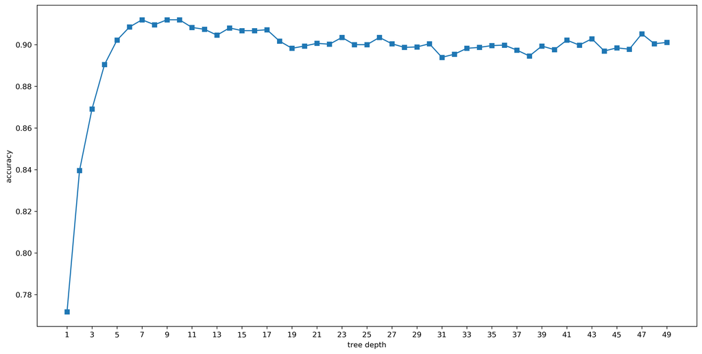

```python
accuracy_df = pd.DataFrame(depth, columns = ['depth','accuracy'])

import matplotlib.pyplot as plt
plt.figure(figsize=(16,8))
plt.plot(accuracy_df['depth'],accuracy_df['accuracy'], '-s')
plt.xticks(np.arange(min(accuracy_df['depth']), max(accuracy_df['depth'])+1, 2.0))
plt.xlabel('tree depth')
plt.ylabel('accuracy')
```

```python
print(accuracy_df[accuracy_df['accuracy'] == accuracy_df['accuracy'].max()])
```

```
   depth  accuracy
9     10  0.911957
```

```python
from sklearn.metrics import accuracy_score, confusion_matrix

clf = DTC(max_depth=10)

clf.fit(X_train, y_train)

predicted = clf.predict(X_test)

ac=accuracy_score(predicted,y_test)

cm=confusion_matrix(y_test, predicted)
```

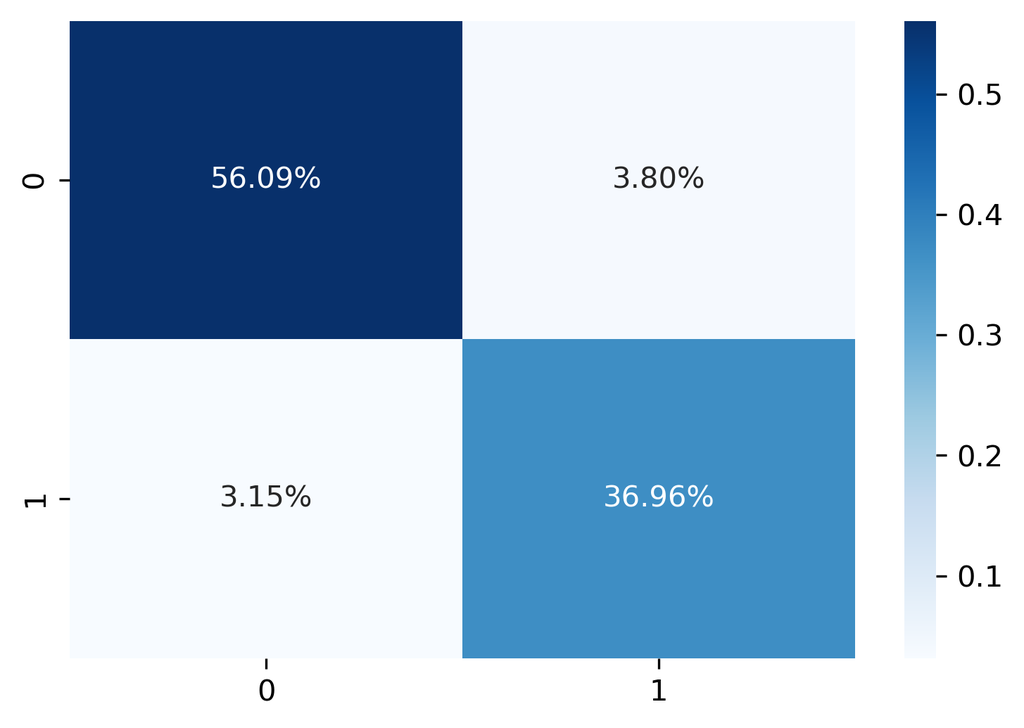

```python
#pyplot.figure(figsize=(2,2))
import seaborn as sns
sns.heatmap(cm/np.sum(cm), annot=True,
            fmt='.2%', cmap='Blues')
```

### QUESTION 3.

```python
from sklearn.ensemble import RandomForestClassifier as RF

clf_rf = RF(n_estimators=20)

clf_rf.fit(X_train, y_train)

rf_predict = clf_rf.predict(X_test)
```

```python
print("Accuracy:",accuracy_score(y_test, rf_predict))
```

```
Accuracy: 0.9543478260869566
```

```python
random_guess_probs = [0 for _ in range(len(y_test))]

pred_probs = clf_rf.predict_proba(X_test)

positive_prob = pred_probs[:, 1]
```

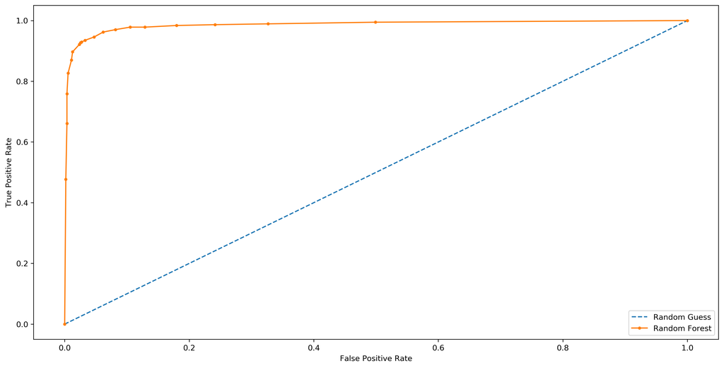

```python
from sklearn.metrics import roc_curve

random_guess_fpr, random_guess_tpr, _ = roc_curve(y_test, random_guess_probs)
pred_fpr, pred_tpr, _ = roc_curve(y_test, positive_prob)

# plot the roc curve for the model
plt.figure(figsize=(16,8))
plt.plot(random_guess_fpr, random_guess_tpr, linestyle='--', label='Random Guess')
plt.plot(pred_fpr, pred_tpr, marker='.', label='Random Forest')
# axis labels
plt.xlabel('False Positive Rate')
plt.ylabel('True Positive Rate')
# show the legend
plt.legend()
# show the plot
plt.show()
```

## PROBLEM 3.

### QUESTION 1

```python
copper = pd.read_csv(os.path.join(base_path, "", "copper-new.txt"),sep = '\s+', names = ['expansion', 'temp'])
#copper
x = copper['temp'].to_numpy().reshape(-1, 1)
y = copper['expansion'].to_numpy().reshape(-1, 1)
```

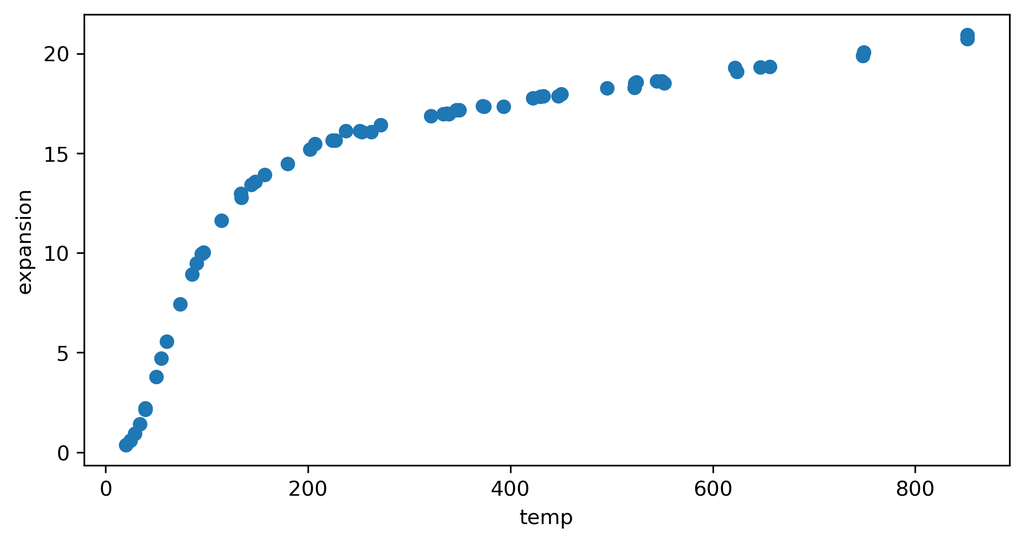

```python
plt.figure(figsize=(8,4))
plt.plot(x,y,'o')
plt.xlabel("temp")
plt.ylabel('expansion')
```

```python
from sklearn.linear_model import LinearRegression as LR

lr_clf = LR().fit(copper['temp'].to_numpy().reshape(-1, 1), copper['expansion'].to_numpy().reshape(-1, 1))

Rsq = lr_clf.score(copper['temp'].to_numpy().reshape(-1, 1), copper['expansion'].to_numpy().reshape(-1, 1))

print("The goodness of fit for the linear regression model is {:.2f}".format(Rsq))
```

```
The goodness of fit for the linear regression model is 0.69
```

### QUESTION 2

> First, I construct the polynomial terms of the original predictor up to degree of 4. Then I set the alpha value to 1e-8 just to try it out. I fit the ridge regression and generate the coefficients and the accuracy.

```python
from sklearn.preprocessing import PolynomialFeatures as PF
from sklearn.linear_model import Ridge
from sklearn.metrics import mean_squared_error as mse

poly_clf = PF(degree = 4)
x_poly = poly_clf.fit_transform(x)

poly_reg = Ridge(alpha = 1e-8, fit_intercept=True,normalize=True)
poly_reg.fit(x_poly, y)

poly_reg_pred = poly_reg.predict(x_poly)
```

```python
mse = sum((poly_reg_pred-y)**2)/len(y)
mse
```

```
array([0.21974485])
```

```python
coef = poly_reg.coef_
coef
```

```
array([[ 0.00000000e+00,  1.80581711e-01, -5.76733822e-04,
         7.91416335e-07, -3.81269358e-10]])
```

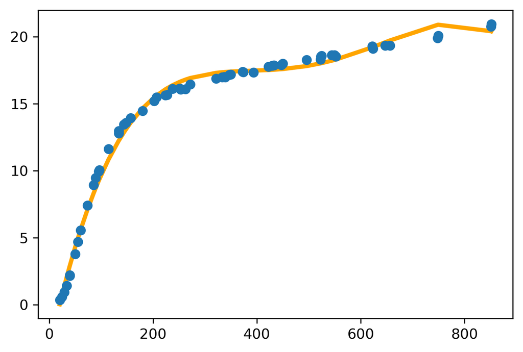

```python
xs, poly_pred_s = zip(*sorted(zip(x, poly_reg_pred)))
plt.plot(xs,poly_pred_s, color = "orange", linewidth = 3, label = 'regression line')
plt.plot(x,y,'o')
```

### QUESTION 3.

```python
from sklearn.model_selection import GridSearchCV
ridge = Ridge(fit_intercept=True, normalize=True)
parameters = {"alpha":[1e-15,1e-10,1e-8,1e-6,1e-5,1e-4,1e-3,1e-2, 0.1, 1, 5, 20]}
ridge_regressor = GridSearchCV(ridge, parameters, scoring = "neg_mean_squared_error", cv =5)
ridge_regressor.fit(x_poly, y)

print(ridge_regressor.best_params_)
print(ridge_regressor.best_score_)
```

```
{'alpha': 1e-05}
-5.016188867681876
```

```python
from sklearn.model_selection import KFold

kf = KFold(n_splits=5, random_state=99, shuffle=True)
kf.get_n_splits(x)

train_index = []
test_index = []
for train_, test_ in kf.split(x):
    train_index.append(train_)
    test_index.append(test_)
```

```python
alpha_mse_compare = []
coef_compare = []

i = 1
while i <= 5:

    x_train, x_test, y_train, y_test = x[train_index[i-1]], x[test_index[i-1]], y[train_index[i-1]], y[test_index[i-1]]

    xtrain_poly = poly_clf.fit_transform(x_train)
    xtest_poly = poly_clf.fit_transform(x_test)

    mse_list = []
    coef_list = []

    for a in [1e-12,1e-10,1e-8,1e-6,1e-5,1e-4,1e-3,1e-2, 0.1, 1, 5, 20]:

        poly_clf = PF(degree = 4)

        poly_reg = Ridge(alpha = a, fit_intercept=True, normalize=True)
        poly_reg.fit(xtrain_poly, y_train)

        poly_reg_pred = poly_reg.predict(xtest_poly)

        mse = np.sum((poly_reg_pred - y_test)**2)/len(y_test)
        coef = poly_reg.coef_

        mse_list.append(mse.item())
        coef_list.append(coef)

    alpha_mse_compare.append(mse_list)
    coef_compare.append(coef_list)

    i += 1
```

#### The mean squared error of each alpha value config is shown below

```python
pd.DataFrame(alpha_mse_compare, columns =  ["1e-12","1e-10","1e-8","1e-6","1e-5","1e-4","1e-3","1e-2", "0.1", "1", "5", "20"],
            index = ['fold1','fold2','fold3','fold4','fold5'])
```

|  | 1e-12 | 1e-10 | 1e-8 | 1e-6 | 1e-5 | 1e-4 | 1e-3 | 1e-2 | 0.1 | 1 | 5 | 20 |
| --- | --- | --- | --- | --- | --- | --- | --- | --- | --- | --- | --- | --- |
| fold1 | 0.197621 | 0.197621 | 0.197620 | 0.198304 | 0.252533 | 1.090482 | 2.454267 | 6.007556 | 12.205223 | 24.494917 | 33.356321 | 39.122220 |
| fold2 | 0.231541 | 0.231541 | 0.231481 | 0.226162 | 0.219039 | 0.714502 | 1.508790 | 3.501561 | 6.420197 | 12.597289 | 19.363191 | 25.257334 |
| fold3 | 0.229888 | 0.229887 | 0.229850 | 0.226755 | 0.241611 | 0.831176 | 1.387070 | 2.982270 | 5.083988 | 9.099110 | 14.403067 | 19.092561 |
| fold4 | 0.329938 | 0.329939 | 0.330081 | 0.344383 | 0.479478 | 1.355574 | 2.669387 | 6.828154 | 15.085698 | 31.454080 | 43.613550 | 51.521966 |
| fold5 | 8.810193 | 8.810118 | 8.802672 | 8.085743 | 3.556849 | 3.558467 | 9.025646 | 6.164636 | 8.323849 | 12.985634 | 9.833591 | 15.883639 |

```python
mean_mse = np.array(alpha_mse_compare).mean(axis = 0)
print(mean_mse)
```

```
[ 1.95983605  1.95982124  1.95834078  1.81626964  0.94990218  1.51004007
  3.40903183  5.09683533  9.42379099 18.12620602 24.11394391 30.17554428]
```

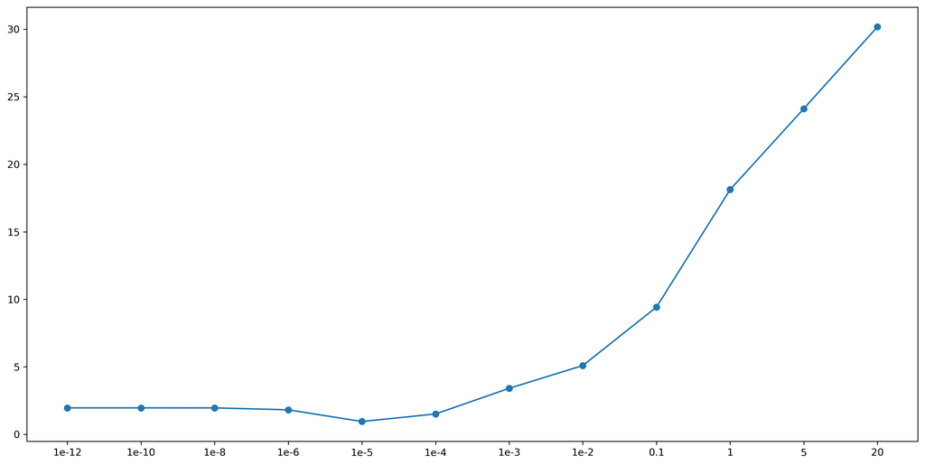

```python
plt.figure(figsize=(16,8))
plt.plot(["1e-12","1e-10","1e-8","1e-6","1e-5","1e-4","1e-3","1e-2", "0.1", "1", "5", "20"],
        mean_mse, marker='o')
```

> We can clearly see that when lambda is set at 1e-5, the mse is the lowest.

Now we can check the coefficients at each lambda value. We can see that there's no intercept

```python
pd.set_option('display.float_format', '{:.3g}'.format)
pd.DataFrame(np.array(coef_compare[0]).reshape(12,5).transpose(),
             index =  ["coef1","coef2","coef3", "coef4", "coef5"],
            columns = ["1e-12","1e-10","1e-8","1e-6","1e-5","1e-4","1e-3","1e-2", "0.1", "1", "5", "20"])
```

|  | 1e-12 | 1e-10 | 1e-8 | 1e-6 | 1e-5 | 1e-4 | 1e-3 | 1e-2 | 0.1 | 1 | 5 | 20 |
| --- | --- | --- | --- | --- | --- | --- | --- | --- | --- | --- | --- | --- |
| coef1 | 0 | 0 | 0 | 0 | 0 | 0 | 0 | 0 | 0 | 0 | 0 | 0 |
| coef2 | 0.181 | 0.181 | 0.181 | 0.179 | 0.165 | 0.117 | 0.0816 | 0.0471 | 0.0225 | 0.00735 | 0.00266 | 0.000872 |
| coef3 | -0.000576 | -0.000576 | -0.000576 | -0.000566 | -0.000495 | -0.000252 | -0.000101 | -2.86e-05 | 3.18e-06 | 4.35e-06 | 2.27e-06 | 8.27e-07 |
| coef4 | 7.87e-07 | 7.87e-07 | 7.86e-07 | 7.7e-07 | 6.42e-07 | 2.15e-07 | -1.79e-08 | -2.34e-08 | -5.78e-09 | 2.35e-09 | 2.12e-09 | 8.49e-10 |
| coef5 | -3.77e-10 | -3.77e-10 | -3.77e-10 | -3.68e-10 | -2.95e-10 | -5.22e-11 | 6.63e-11 | 1.94e-11 | -9.48e-12 | 7.79e-13 | 2.05e-12 | 8.94e-13 |

### QUESTION 4.

```python
coef_compare[0][4]
```

```
array([[ 0.00000000e+00,  1.64941341e-01, -4.94522105e-04,
         6.42287199e-07, -2.94857292e-10]])
```

```python
x_mean = np.mean(x_poly, axis = 0)
x_norm = np.linalg.norm(x_poly, ord =2, axis = 0)
print(x_mean)
print(x_norm)
```

```
[1.00000000e+00 3.17734915e+02 1.51741247e+05 8.68071973e+07
 5.51925080e+10]
[7.68114575e+00 2.99211189e+03 1.80453816e+06 1.26415610e+09
 9.56609425e+11]
```

```python
x_400 = (np.array([1, 400, 400**2, 400*3, 400**4])-x_mean)/x_norm
print(x_400)
```

```
[ 0.          0.02749399  0.00457666 -0.06866715 -0.03093479]
```

```python
F_expansion = x_400.dot(coef_compare[0][4].flatten())
F_expansion = F_expansion*np.linalg.norm(y, ord = 2) + np.mean(y)
F_expansion
```

```
14.678700550798316
```

```python
poly_reg = Ridge(alpha = 1e-5, fit_intercept=True,normalize=True)
poly_reg.fit(x_poly, y)
poly_reg_pred = poly_reg.predict(x_poly)
```

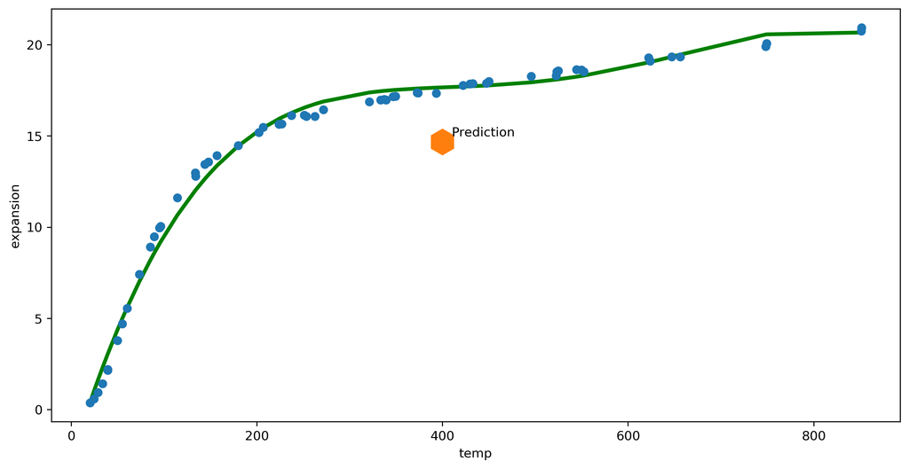

```python
plt.figure(figsize=(12,6))
xs, poly_pred_s = zip(*sorted(zip(x, poly_reg_pred)))
plt.plot(xs,poly_pred_s, color = "green", linewidth = 3, label = 'regression line')
plt.plot(x,y,'o')
plt.plot(400, F_expansion,marker = 'h', markersize=20 )
plt.annotate('Prediction', (400, F_expansion),xytext = (410,15))
plt.xlabel("temp")
plt.ylabel('expansion')
```

> As is shown in the plot, the prediction is lower than the trend that's observed in the data. This is probably due to the degree of the polynomials being higher than neccessary. And also the normalization of the data might also have an impact because we do not know whether the new input data will follow the distribution of the previous dataset sample.

## PROBLEM 4.

### QUESTION 1.

#### ANSWER

> \begin{align} \hat{\beta}(\lambda) = {argmin}_{\beta}\{\frac{1}{n}\sum^n_{i=1}(y_i-x^T\beta)^2+\lambda||\beta||_2^2\}\\ \ = {argmin}_{\beta}\{\frac{1}{n}\sum^n_{i=1}y_i^2+(x^T\beta)^2 - 2x_i^Ty\beta+\lambda||\beta||_2^2\}\\ \frac{d\hat{\beta}(\lambda)}{d\beta} = \frac{1}{n}\sum^n_{i=1}2(x^T)^2\beta - 2x^Ty+2\lambda\beta\\ \end{align} Let $$\frac{d\hat{\beta}(\lambda)}{d\beta} = 0$$\ \begin{align} (x^T)^2\beta^* - x^Ty+\lambda\beta^* = 0\\[12pt] (x x^T+\lambda)\beta^* = x^Ty\\[12pt] \beta^* = (x x^T+\lambda I)^{-1} x^Ty \end{align}

> We can see from the closed form that $\beta^*$ is essentially a linear combination of $y$, and because $y$ follows gaussian distribution, therefore, $\beta^*$ is also gaussian distributed. The reason why $y$ follows gaussian distribution is because $y = \beta x + \epsilon$,and $\epsilon$ is also gaussian distributed: $\epsilon \sim \mathcal{N}(0,\sigma^2)$.\

> Therefore, \begin{align} \mathrm{E}[Y] &= \mathrm{E}[ x\beta] + \mathrm{E}[\epsilon]\\ & = x \tag{1} \end{align}

> and \begin{align} \mathrm{Var}[Y] &= \mathrm{E}[{(y - \bar y)^2}] = \mathrm{E}(y^2) - (\mathrm{E}[y])^2 \tag{2} \end{align}

> Proof of (2): \begin{align} \mathrm{Var}[x] &= \sum_x(x-\bar x)^2 Pr(X=x)\\ & = \sum_x(x^2-2x\bar x + \bar x^2)^2 Pr(X=x)\\ & = \sum_x x^2 Pr(X=x) -2\bar x^2 + \sum_x xPr(X=x) + \sum_x \bar x^2 Pr(X=x)\\ & = \sum_x x^2 Pr(X=x) -2\bar x^2 + \bar x^2\\ & = \mathrm{E}[x^2] - \bar x^2 \end{align} (by definition, $\sum_x xPr(X=x)$ is the mean of x, ie $\bar x$, and also the expectation of $x$)

Therefore, \begin{align} \mathrm{Var}[Y] &= \mathrm{E}[{(y - \bar y)^2}] = \mathrm{E}(y^2) - (\mathrm{E}[y])^2\\ & = \mathrm{E}[(x\beta )^2 + 2x\beta \epsilon + \epsilon^2] - (x\beta )^2\\ & = \mathrm{E}[(x\beta )^2] + \mathrm{E}[2\beta x \epsilon] + \mathrm{E}[\epsilon^2] - (x\beta )^2\\ & = (x\beta )^2 + 2\beta x \mathrm{E}[\epsilon] + \mathrm{E}[\epsilon^2] - (x\beta )^2\\ & = 2x\beta *0 + \mathrm{E}[\epsilon^2] \\ & = \mathrm{E}[\epsilon^2] = \sigma^2 \tag{3} \end{align}

> The expectation of $\hat{\beta}$: \begin{align} \mathrm{E}[\hat{\beta}(\lambda)] &= \mathrm{E}[(x x^T+\lambda I)^{-1} x^Ty]\\ & =(x x^T+\lambda I)^{-1} x^T *\mathrm{E}[y]\\ & =(x x^T+\lambda I)^{-1} x^T x\beta^*\\ \tag{4} \end{align}

The variance of $\hat{\beta}$: \begin{align} \mathrm{Var}[\hat{\beta}(\lambda)] &= \mathrm{Var}[(x x^T+\lambda I)^{-1} x^Ty]\\ &=(x x^T+\lambda I)^{-1} x^T *\mathrm{Var}[y_i] *((x x^T+\lambda I)^{-1} x^T)^T\\ &=(x x^T+\lambda I)^{-1} x^T *\sigma^2 *((x x^T+\lambda I)^{-1}x^T)^T \\ &=\sigma^2 x^T (x x^T+\lambda I)^{-1}((x x^T+\lambda I)^{-1})x^T)^T\\ \tag{5} \end{align}

> Conclusion: The $\hat{\beta}(\lambda)$ function is a gaussian distribution with first moment as $$(x x^T+\lambda I)^{-1} x^T x \beta^*$$, and second moment as $$\sigma^2 x^T (x x^T+\lambda I)^{-1}((x x^T+\lambda I)^{-1})x^T)^T$$

### QUESTION 2.

#### ANSWER

> \begin{align} \mathrm{E}[x^T \hat{\beta}(\lambda) ] - x^T\beta^* & = \mathrm{E}[x^T (xx^T+\lambda I)^{-1}x^T y] - x^T\beta^*\\ & = x^T (xx^T+\lambda I)^{-1}x^Tx\beta^* - x^T\beta^*\\ & = x^T(xx^T+\lambda I)^{-1}(x^Tx\beta -(xx^T+\lambda I)\beta^*)\\ & = -\lambda x^T(xx^T + \lambda I)^{-1}\beta^*\\ \tag{6} \end{align}

### QUESTION 3.

#### ANSWER

> \begin{align} \mathrm{E}[(x^T\hat{\beta}(\lambda) - \mathrm{E}[x^T\hat{\beta}(\lambda)])^2] &= \mathrm{Var}[x^T\hat{\beta}(\lambda)]\\ & = \mathrm{Var}[x^T(x x^T+\lambda I)^{-1} x^Ty]\\ & = x^T(x x^T+\lambda I)^{-1} x^T \sigma^2 x((x x^T+\lambda I)^{-1})^T x\\ \tag{8} \end{align}

### QUESTION 4.

#### ANSWER

> It can be observed that when \lambda increases, the $bias^2$ increases, while the variance decreases. When $\lambda$ is small, the variance is larger than the bias, and when $\lambda$ is large, the bias is larger than the variance.